# Metric Learning

zjx

2020/5/3

# Prediction evaluation metric: loss function

In general, [learning consists of three compoents](https://dl.acm.org/doi/pdf/10.1145/2347736.2347755):
$$\text{Learning=Representation + Evaluation + Optimization}.$$

[The prediction evaluation metric should be selected to reflect domain-specific considerations, such as the types of errors that are more costly.](https://www.stat.berkeley.edu/~binyu/ps/papers2020/VDS20-YuKumbier.pdf) [In fact, there is an entire area of research devoted to evaluating the quality of probabilistic forecasts through “scoring rules”.](https://www.stat.washington.edu/raftery/Research/PDF/Gneiting2007jasa.pdf)

- https://rohanvarma.me/Loss-Functions/
- [Probabilistic Setup and Empirical Risk Minimization](https://ttic.uchicago.edu/~tewari/lectures/lecture7.pdf)
- [10: Empirical Risk Minimization](https://www.cs.cornell.edu/courses/cs4780/2018fa/lectures/lecturenote10.html)
- [Principles of risk minimization for learning theory](http://papers.nips.cc/paper/506-principles-of-risk-minimization-for-learning-theory.pdf)
- https://ml-cheatsheet.readthedocs.io/en/latest/loss_functions.html

| Loss function | Cost function | Empirical risk | Structure risk |
| --- | --- | --- | --- |
| $L(y , f(x , a))$ between the response $y$ of the supervisor to a given input $x$ and the response $f(x, a )$ provided by the learning machine | the objective function to minimize | approximation to the expected value of the loss | regularized emprical risk |

In absence of prior knowledge about data we can only use general purpose metrics like Euclidean distance, Cosine similarity or Manhattan distance etc, but these metric often fail to capture the correct behavior of data which directly affects the performance of the learning algorithm. Solution to this problem is to tune the metric according to the data and the problem, manually deriving the metric for high dimensional data which is often difficult to even visualize is not only tedious but is extremely difficult. Which leads to put effort on metric learning which satisfies the data geometry. [Goal of metric learning algorithm is to learn a metric which assigns small distance to similar points and relatively large distance to dissimilar points](https://parajain.github.io/metric_learning_tutorial/)

- https://parajain.github.io/metric_learning_tutorial/
- https://en.wikipedia.org/wiki/Similarity_learning

## Maximum likelihood estimate

Let us begin with the maximum likelihood estimate(mle). In statistics, the **likelihood principle** is the proposition that, given a statistical model, all the evidence in a sample relevant to model parameters is contained in the likelihood function. In maximum likelihood estimate (mle）, the sample $\{x_i\}_{i=1}^{N}$ are identitically independently from a probability distribution $\mathcal{P}(\theta)$, so that we can obtain their joint probability
$$P(x_1,\cdots,x_n)=\prod_{i=1}^N P(\theta;x_i)$$
where $P(\theta;x_i)\in [0, 1]$ is the probability of $x_i$. It is also called the likelihood of the parameter $\theta$. Here $P(\theta;x_i)$ is point in the probability (distribution) function at the point $x_i$ and $P(\theta;x)$ is parameterized by $\theta\in \Theta$. In another word, we know the distribution family $\mathcal P$ parametrized $\theta\in \Theta$.

Because we have observed that samples $x_i$ generated from the probability (distribution) family $P(\theta)$, the joint probability of $\{x_i\}_{i=1}^{N}$ cannot be zero. If $P(x_1,\cdots,x_n)$ is too small, the event is rare to observe. Thus it should be common enough for us to observe. The maximum likelihood estimate (mle) of $\theta$ is the one that maximize the joint probability
$$\begin{equation}\label{mle}
\theta^{\ast}=\arg\max_{\theta\in \Theta} P(x_1,\cdots,x_n)=\arg\max_{\theta\in \Theta} \prod_{i=1}^N P(\theta;x_i).\end{equation}$$

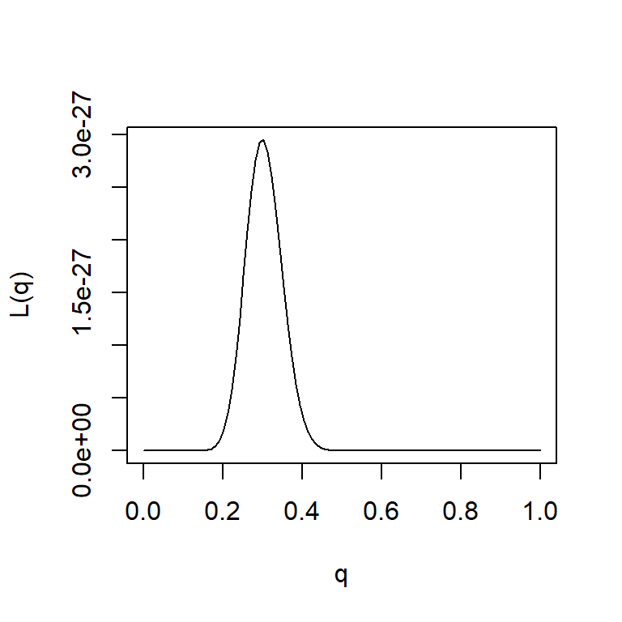

Because likelihoods may be very small numbers, the product of the likelihoods can get very small very fast and can exceed the precision of the computer. Because we only care about the relative likelihood, the convention is to work with the log-likelihoods instead, because `the log of a product is equal to the sum of the logs`. Therefore, we can take of the logarithm of each individual likelihood and add them together and get the same end result, i.e., the parameter value that maximizes the likelihood ($L$) is equal to the parameter value that maximizes the log-likelihood $\ell$:
$$\begin{equation}\label{log-likelihood}\ell=\log(\prod_{i=1}^N P(\theta;x_i))=\sum_{i=1}^{N}\log P(\theta;x_i)\end{equation}$$
where $\log P(\theta;x_i)\leq 0$. Because the logarithm function is monotonic and inverse, so that
$$\theta^{\ast}=\arg\max_{\theta\in \Theta} P(x_1,\cdots,x_n)=\arg\max_{\theta\in \Theta} \sum_{i=1}^{N}\log P(\theta;x_i).$$

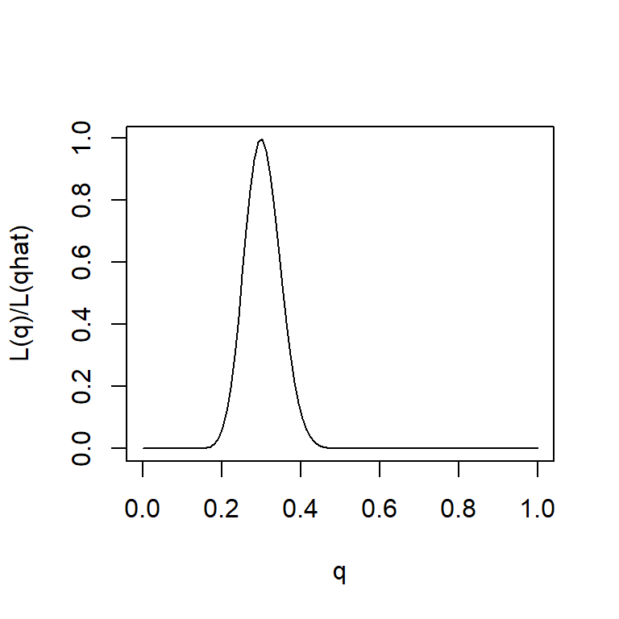

Given our goodness(or badness)-of-fit measure, our next step is to find the values of the parameters that give us the best fit – the so-called `maximum likelihood estimators`. In short, we convert the parameter inference into the numerical optimization.

- [Likelihood Ratios, Likelihoodism, and the Law of Likelihood](https://plato.stanford.edu/entries/logic-inductive/sup-likelihood.html)
- https://algorithmia.com/blog/introduction-to-loss-functions
- [Analysis of Environmental Data Conceptual Foundations: Maximum Likelihood Inference](https://www.umass.edu/landeco/teaching/ecodata/schedule/likelihood.pdf)

Note the following relation
$$\theta^{\ast}=\arg\max_{\theta\in \Theta} \sum_{i=1}^{N}\log P(\theta;x_i) = \arg\max_{\theta\in \Theta}\frac{1}{N} \sum_{i=1}^{N}\log P(\theta;x_i)$$
where $N$ is a constant positive number.

Now we regard the term $\log P(\theta;x_i)$ as an transformation of the observation,
$$\theta^{\ast}
=\arg\max_{\theta\in \Theta}\mathbb{E}_{x\sim \hat{p}(x)} \log P(\theta;x)\\
=\arg\min_{\theta\in \Theta} -\mathbb{E}_{x\sim \hat{p}(x)} \log P(\theta;x)\\
=\arg\min_{\theta\in \Theta} \mathbb{E}_{x\sim \hat{p}(x)} -\log P(\theta;x)\\
=\arg\min_{\theta\in \Theta} \mathbb{E}_{x\sim \hat{p}(x)} \log\frac{1}{P(\theta;x)}.$$
As $N\to\infty$, this average log-likelihood function tends, with probability 1,

$$\mathbb{E}_{x\sim \hat{p}(x)} \log\frac{1}{P(\theta;x)}=\mathbb{E}_{x\sim {p}^{true}(x)} \log\frac{1}{P(\theta;x)}\\
=\int_{x}p^{true}(x)\log\frac{1}{p(\theta;x)}\mathrm dx\\
=\int_{x}p^{true}(x)\log\frac{1}{p(\theta;x)}\mathrm dx+\underbrace{\int_{x}p^{true}(x)\log{p^{true}(x)}\mathrm dx}_{constant}-\underbrace{\int_{x}p^{true}(x)\log{p^{true}(x)}\mathrm dx}_{constant}\\
=\int_{x}p^{true}(x)\log\frac{p^{true}(x)}{p(\theta;x)}\mathrm dx- \underbrace{\int_{x}p^{true}(x)\log{p^{true}(x)}\mathrm dx}_{constant}\\
=KL(p^{true}(x)\mid p(\theta;x))-\underbrace{\int_{x}p^{true}(x)\log{p^{true}(x)}\mathrm dx}_{constant}$$

where ${p}^{true}(x)$ is the true probability distribution function of $x$.

So we conclude that
$$\theta^{\ast}=\arg\min_{\theta\in \Theta} KL(p^{true}(x)\mid p(\theta;x))=\arg\min_{\theta\in \Theta}\log\frac{p^{true}(x)}{p(\theta;x)}$$
as $N\to\infty$.

In this sense, mle is to find the optimal approximation to the true probability distribution function constained in the probability distribution function family $p(\theta;\cdot)$ given some observation.

- [Alternative form of max likelihood](https://cedar.buffalo.edu/~srihari/CSE676/5.5%20MLBasics-MaxLikelihood.pdf)
- [Maximum Likelihood as minimising KL Divergence](https://www.jessicayung.com/maximum-likelihood-as-minimising-kl-divergence/)
- [Why Minimize Negative Log Likelihood?](https://quantivity.wordpress.com/2011/05/23/why-minimize-negative-log-likelihood/)

The loss function of mle is based on the probability distribution family.

For example, $x_i\in \{0, 1\}\sim Bernoulli(p)$, the log-likelihood of $\{x_i\}_{i=1}^N$ is
$$\ell(p)=\log(\prod_{i=1}^{N}p^{x_i}(1-p)^{1-x_i})=\sum_{i=1}^N (x_i\log p+(1-x_i)\log (1-p))\\=\sum_{i=1}^N(x_i\log\frac{p}{1-p}+\log(1-p))\\=(\sum_{i=1}^Nx_i)\log\frac{p}{1-p}+n\log(1-p).$$
To find the mle, we set the derivative of $\ell(p)$ to zero
$$\frac{\mathrm d \ell(p)}{\mathrm d p}=(\sum_{i=1}^Nx_i)(\frac{1}{p}+\frac{1}{1-p})-\frac{n}{1-p}=0$$
and we get $p^{\ast}=\arg\max_{p}\ell(p)=\frac{(\sum_{i=1}^Nx_i)}{n}$.

For example, $x_i\sim Poisson(\lambda)$, the log-likelihood of $\{x_i\}_{i=1}^N$ is
$$\ell(\lambda)=\log(\prod_{i=1}^{N}\frac{\lambda^{x_i}\exp(-\lambda)}{x_i!})=\sum_{i=1}^N [x_i\log(\lambda)-\log x_i!]-N\lambda\propto \sum_{i=1}^N x_i\log(\lambda)-N\lambda$$
To find the mle, we set the derivative of $\ell(\lambda)$ to zero
$$\frac{\mathrm d \ell(\lambda)}{\mathrm d \lambda}=\sum_{i=1}^N\frac{x_i}{\lambda}-N=0$$
and we get $\lambda=\frac{\sum_{i=1}^N x_i}{N}$.

Let $x_1, \cdots , x_N$ be i.i.d. samples with Laplace density
$$P(\theta\mid \cdot)=\frac{1}{2}\exp(-\|x-\theta\|_1)$$
where $\theta\in\mathbb{R}$. Their log-likelihood is
$$\ell(\theta)=\log(\prod_{i=1}^NP(\theta\mid x_i))=\log(\prod_{i=1}^N\frac{1}{2}\exp(-\|x_i-\theta\|_1)=-N\log(2)-\sum_{i=1}^N\|x_i-\theta\|_1$$
Observe that
$$\hat{\theta}=\arg\max_{\theta}\ell(\theta)=\arg\max_{\theta}-\sum_{i=1}^N\|x_i-\theta\|_1\\=\arg\min_{\theta}\underbrace{\sum_{i=1}^N\|x_i-\theta\|_1}_{\text{convex}}.$$
According to convex optimization, $0\in\partial \sum_{i=1}^N\|x_i-\hat\theta\|_1$ thus $\sum_{i=1}^N\operatorname{sgn}(x_i-\hat\theta)=0\implies \hat\theta=\operatorname{median}\{x_1,\cdots,x_N\}$.

- https://www.colorado.edu/amath/sites/default/files/attached-files/ch4.pdf
- https://rpubs.com/FJRubio/logisMLE
- https://shodhganga.inflibnet.ac.in/bitstream/10603/21266/12/12_chapter%206.pdf

### Bayesian mle

Sometimes, domain-specific experience will tell us how to select some appropriate parameters of the probiality distribution functions.

[For example, adult male heights are on average 70 inches (5’10) with a standard deviation of 4 inches. Adult women are on average a bit shorter and less variable in height with a mean height of 65 inches (5’5) and standard deviation of 3.5 inches.](https://www.usablestats.com/lessons/normal)

However, we know that human heights cannot be negative. It is better to use the truncated normal distribution for adult heights. The parameters must be compatible with the domain-specific experience.

[There’s one key difference between frequentist statisticians and Bayesian statisticians that we first need to acknowledge before we can even begin to talk about how a Bayesian might estimate a population parameter $\theta$.](https://online.stat.psu.edu/stat414/node/241/) Bayesians describe the mapping from prior beliefs about $\theta$, summarized in so-called prior density of $P(\theta)$, to new posterior beliefs in the light of observing the data.

[Maximum A Posteriori (MAP) estimator](https://web.stanford.edu/class/archive/cs/cs109/cs109.1166/ppt/22-MAP.pdf) of $\theta$ is to maximize the posteriori of $\theta$
$$\theta^{\ast}=\arg\max_{\theta\in \Theta}P(\theta\mid x)\\=\arg\max_{\theta\in \Theta}\frac{P(\theta, x)}{P(x)}\\=\arg\max_{\theta\in \Theta}\frac{P(x\mid \theta)P(\theta)}{P(x)}\\=\arg\max_{\theta\in \Theta} P(x\mid \theta)P(\theta)$$
where $P(x)$ is the function of random variable.

`Bayesian maximum likelihood estimate` is to maximize the likelihood with a penalty function
$$\begin{equation}\label{Bayesian mle}\theta^{\ast}=\arg\max_{\theta\in \Theta}\sum_{i=1}^{N}\log P(\theta;x_i)+\log P(\theta)\end{equation}$$
where $\sum_{i=1}^{N}\log P(\theta;x_i)$ is the likelihood of the parameter $\theta$ and $P(\theta)$ is the prior probability density function of $\theta$.

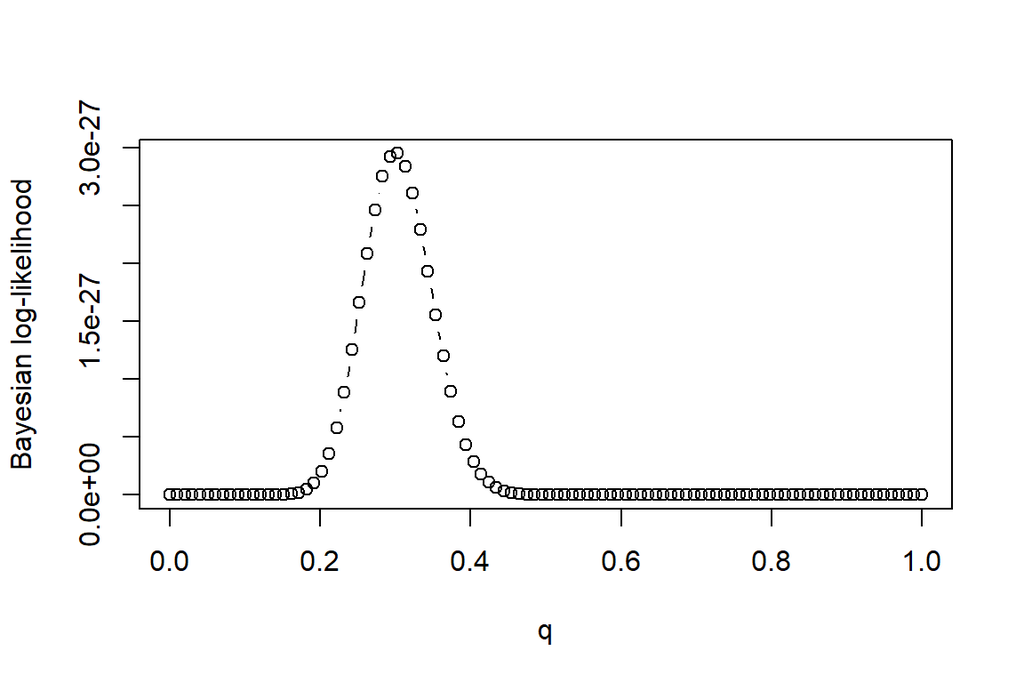

MAP estimate is the `mode of the posterior distribution`. Another option of Bayesian estimate would be to choose the `posterior mean`
$$\begin{equation}\label{MMSE}\hat{\theta}=\mathbb E[\theta|X=x]=\int_{\theta\in\Theta}\theta P(\theta\mid x)\mathrm d \theta.\end{equation}$$
It is called minimum mean squared error (MMSE) estimate of the random variable $\theta$ given $x$.

- [Bayesian Maximum Likelihood](http://faculty.wcas.northwestern.edu/~lchrist/course/CIED_2012/bayesian.pdf)
- [Maximum Likelihood vs.Bayesian Estimation](http://www-edlab.cs.umass.edu/cs689/lectures/ml-vs-bayes-estimation.pdf)
- [9.1.2 Maximum A Posteriori (MAP) Estimation](https://www.probabilitycourse.com/chapter9/9_1_2_MAP_estimation.php)
- [9.1.4 Conditional Expectation (MMSE)](https://www.probabilitycourse.com/chapter9/9_1_4_conditional_expectation_MMSE.php)
- [ML, MAP, and Bayesian — The Holy Trinity of Parameter Estimation and Data Prediction](https://engineering.purdue.edu/kak/Trinity.pdf)

Suppose that $Y$ follows a binomial distribution with parameters $n$ and $p = \theta$, so that the p.m.f. of $Y$ given $\theta$ is:
$$g(y|\theta) = \binom{n}{y}\theta^y(1-\theta)^{n-y}$$
for $y = 0, 1, 2, \cdots, n$. Suppose that the prior p.d.f. of the parameter $\theta$ is the beta p.d.f., that is:
$$h(\theta)=\frac{\Gamma(\alpha+\beta)}{\Gamma(\alpha)\Gamma(\beta)}\theta^{\alpha-1}(1-\theta)^{\beta-1}$$
for $0 < \theta < 1$. Find the posterior p.d.f of $\theta$, given that $Y = y$.

First we obtain the joint density function by multiplying the prior and conditional probability
$$P(y,\theta)=g(y|\theta)h(\theta)=\binom{n}{y}\theta^y(1-\theta)^{n-y}\frac{\Gamma(\alpha+\beta)}{\Gamma(\alpha)\Gamma(\beta)}\theta^{\alpha-1}(1-\theta)^{\beta-1}\\=\underbrace{\binom{n}{y}\frac{\Gamma(\alpha+\beta)}{\Gamma(\alpha)\Gamma(\beta)}}_{\text{normalization factor}}\theta^{y+\alpha-1}(1-\theta)^{n-y+\beta-1}$$
and
$$\theta^{\ast}=\arg\max_{\theta\in (0, 1)}\log(k(y,\theta))=\arg\max_{\theta\in (0, 1)}(y+\alpha-1)\log(\theta)+(n-y+\beta-1)\log(1-\theta).$$
By settingthe derivative of the log-likelihood function be 0, we obtain the following equation
$$(y+\alpha-1)(1-\theta)-\theta(n-y+\beta-1)=y+\alpha-1-\theta(n-y+\beta-1+y+\alpha-1)=0$$
we obtain $\theta=\frac{y+\alpha-1}{n+\alpha+\beta-2}$ so $\theta^{\ast}=\frac{y+\alpha-1}{n-2+\beta+\alpha}$.

And $P(\theta\mid y)=\int_{y}P(y,\theta)\mathrm d y\propto \theta^{y+\alpha-1}(1-\theta)^{n-y+\beta-1}$. In another word, $\theta\mid y$ follows a $Beta$ distribution, and
$$\mathbb E(\theta\mid y)=\frac{y+\alpha}{n+\alpha+\beta}.$$

- [Notes for 6.864, ML vs. MAP (Sept. 24, 2009)](http://people.csail.mit.edu/regina/6864/mlvsmap.pdf)
- [Bayesian Estimation](https://online.stat.psu.edu/stat414/node/241/)

The mle only takes the samples $\{x_i\}_{i=1}^N$ into consideration while Bayesian mle also considers the parameters.

| mle | Bayesian mle |
| --- | --- |
| point estimation of density function | Bayesian inference |
| $\arg\max_{\theta\in\Theta}P(x\mid\theta)$ | $\arg\max_{\theta\in\Theta}P(x\mid\theta)P(\theta)$ |
| $\theta$ is as the unknown parameter of the probability $P(x\mid \theta)$. | $\theta$ is the latent random factor to measure the rareness of the model $P(\cdot\mid \theta)$. |

Bayesian mle is to find the frequent pattern of the model. MAP is to answer the question what is the most possible pattern in the belief of $P(\theta)$ if we have observed a sequence of samples generated by a model parameterized by $\theta$.

Bayesian estimates constraint the probability distribution of parameter $\theta$ so it is to rule out some chances. The prior $P(\theta)$ penalize the rare values of parameters. The core of Bayesian statistics is to use the prior probability of the parameters to decrease their uncertainty.

According to the product rule of probability, we can find that
$$P(x,\theta)=P(x\mid \theta)P(\theta)=P( \theta\mid x)P(x)\implies P( \theta\mid x)=\frac{P(x\mid \theta)P(\theta)}{P(x)}\propto P(x\mid \theta)P(\theta).$$

It is summarized as following `posterior is proportional to likelihood times prior`.

In standard Bayesian notation, we use $\pi(\theta)$ to denote the `prior probability density function (pdf)` of parameter $\theta$ with support$S(\theta)$, $L(y|\theta)$ the `likelihood function` (i.e. the pdf of data given the parameter) with support $S(Y |\theta)$, $p(\theta|y)$ the `posterior pdf` with support $S(\theta\mid Y)$ of parameter given the data, and $f(y)$ the unconditional pdf for the data with support $S(Y)$. Both $\theta$ and $y$ can be vectors.

From the joint pdf identity, $L(y|\theta)\pi(\theta) = p(\theta|y)f(y)$, the `Bayes formula`
$$p(\theta|y)=\frac{L(y|\theta)\pi(\theta)}{f(y)}=\frac{L(y|\theta)\pi(\theta)}{\int_{S(\theta\mid Y)}L(y|\theta)\pi(\theta)}.$$
We can re-write the above joint pdf identity as $f(y)=\frac{L(y|\theta)\pi(\theta)}{p(\theta|y)}$. Now for any fixed $\theta$, we can integrate both sides of the re-expressed joint pdf identity with respect to $y$ over $S(Y\mid \theta)$ and obtain the prior pdf at $\theta$
$$\int_{y\in S(Y\mid \theta)}f(y)\mathrm d y=\pi(\theta)\int_{y\in S(Y\mid \theta)}\frac{L(y|\theta)}{p(\theta|y)}\mathrm d y \\ \Downarrow \\ \pi(\theta)=\frac{\int_{y\in S(Y\mid \theta)}f(y)\mathrm d y}{\int_{y\in S(Y\mid \theta)}\frac{L(y|\theta)}{p(\theta|y)}\mathrm d y}=\int_{y\in S(Y\mid \theta)}f(y)\mathrm d y(\int_{y\in S(Y\mid \theta)}\frac{L(y|\theta)}{p(\theta|y)}\mathrm d y)^{-1}.$$
Under so-called positivity assumption, we will obtain the [Inversion of Bayes formula](https://www.intlpress.com/site/pub/files/_fulltext/journals/sii/2011/0004/0001/SII-2011-0004-0001-a010.pdf):
$$\begin{equation}\label{IBF}\pi(\theta)=(\int_{y\in S(Y\mid \theta)}\frac{L(y|\theta)}{p(\theta|y)}\mathrm d y)^{-1}\end{equation}$$
for $\theta \in S(\theta)$.

If we prefer some posterior pdf, we can use Inversion of Bayes formula to find a proper $\pi(\theta)$.

- [Inversion of Bayes formula](https://www.intlpress.com/site/pub/files/_fulltext/journals/sii/2011/0004/0001/SII-2011-0004-0001-a010.pdf)
- [Inverse Bayes Formulae (IBF)](http://web.hku.hk/~kaing/Section1_3.pdf)
- [Unexpected Journey to the Converse of Bayes’ Theorem](http://web.hku.hk/~kaing/HKSSinterview.pdf)

### Linear Regression

Now we turn to regression problem. Simply speaking, regression is to find the relationship of variables. The common setting of regression problem is training data set $(x_i, y_i)$ for $i=1,\cdots, N$ and the model space $\mathcal{M}=\{m(\theta)\mid \theta\in\Theta\}$, where $x_i\in\mathbb{R}^d$ and $y_i\in\mathbb{R}$. And there is an oracle $m_o\in \mathcal{M}$ so that
$$y_i=m_o(x_i)+\varepsilon_i\tag{regression}$$
for $i=1,\cdots, N$ and $\{\varepsilon_i\}){i=1}^N$ are random variables identically indepentlt distributed in some probability family.

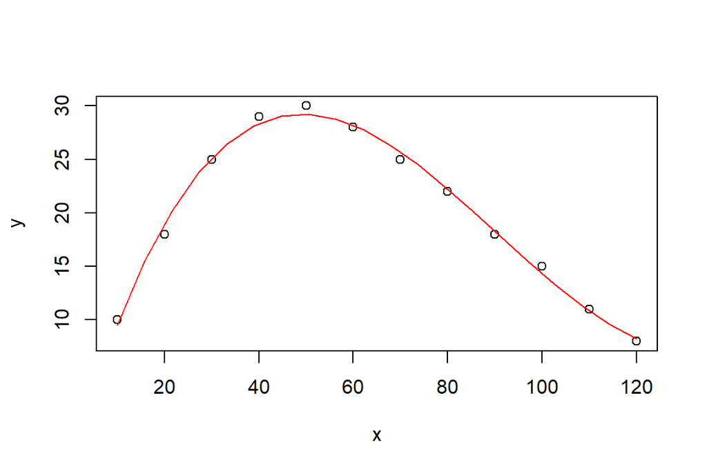

[`The method of least squares` is about estimating parameters by minimizing the `squared discrepancies` between observed data, on the one hand, and their expected values on the other](https://stat.ethz.ch/~geer/bsa199_o.pdf) The least squares estimator, denoted by $\hat{\beta}$, is that value of b that minimizes
$$\sum_{i=1}^{N}(y_i-m(x_i;\theta))^2.\tag{least squares method}$$
In another word,
$$\hat{\beta}=\arg\min_{\theta\in\Theta}\sum_{i=1}^{N}(y_i-m(x_i;\theta))^2=\arg\min_{\theta\in\Theta}\frac{1}{N}\sum_{i=1}^{N}(y_i-m(x_i;\theta))^2\\=\arg\max_{\theta\in\Theta}-\sum_{i=1}^{N}(y_i-m(x_i;\theta))^2=\arg\max_{\theta\in\Theta}\sum_{i=1}^{N}-(y_i-m(x_i;\theta))^2\\=\arg\max_{\theta\in\Theta}\prod_{i=1}^{N}\exp(-(\underbrace{y_i-m(x_i;\theta)}_{\varepsilon_i})^2)\\=\arg\max_{\theta\in\Theta}\prod_{i=1}^{N}\exp(-(\varepsilon_i)^2).$$
In some sense, least squares estimation is equivalent to maximum likelihood estimation with respect to the residual $\varepsilon_i$.

The basic model is the linear model, i.e., $m(x_i)=w\cdot x_i - b=\left<w\,\, b, x_i \,\,1\right>$. Without generality, we set $m(x)=\left<\theta, x\right>$. The `ordinary least squares` estimate is to minimize the $\sum_{i=1}^N (y_i-\left<\theta, x_i\right>)^2$, i.e.,
$$\hat{\theta}=\arg\min_{\theta}\sum_{i=1}^N (y_i-\left<\theta, x_i\right>)^2=\arg\min_{\theta}\|y-X\theta\|_2^2\tag{ordianry least squares}$$
where $y=(y_1,\cdots, y_N)^T$ and $X=(x_1,\cdots,x_N)^T$.

[Ordinary least squares method](https://www.albert.io/blog/key-assumptions-of-ols-econometrics-review/)

- [Least squares and maximum likelihood by M.R.Osborne](https://maths-people.anu.edu.au/~mike/lsnml.pdf)
- [Least squares and maximum likelihood estimation](https://bookdown.org/egarpor/PM-UC3M/app-ext-mle.html)

[Regularization is a popular approach to reducing a model’s predisposition to overfit on the training data and thus hopefully increasing the generalization ability of the model.](https://rohanvarma.me/Regularization/)

[The Lasso is a shrinkage and selection method for linear regression. It minimizes the usual sum of squared errors, with a bound on the sum of the absolute values of the coefficients. It has connections to soft-thresholding of wavelet coefficients, forward stagewise regression, and boosting methods.](http://statweb.stanford.edu/~tibs/lasso.html) The `lasso` estimate is defined as
$$\hat{\theta}=\arg\min_{\theta\in\mathbb{R}^p}\sum_{i=1}^N (y_i-\left<\theta, x_i\right>)^2+\lambda\sum_{i=1}^{p}|\theta_i|=\arg\min_{\theta\in\mathbb{R}^p}\|y-X\theta\|_2^2+\lambda\|\theta\|_1$$

Lasso penalty corresponds to Double-exponential prior: $\arg\min_{\theta\in\mathbb{R}^p}\|y-X\theta\|_2^2+\lambda\|\theta\|_1=\arg\max_{\theta\in\Theta}\exp(-\|y-X\theta\|_2^2)\underbrace{\exp(-\lambda \|\theta\|_1)}_{\text{Double-exponential prior}}$.

Ridge Regression penalty corresponds to Gaussian prior: $\arg\min_{\theta\in\mathbb{R}^p}\|y-X\theta\|_2^2+\lambda\|\theta\|_2^2=\arg\max_{\theta\in\Theta}\exp(-\|y-X\theta\|_2^2)\underbrace{\exp(-\lambda \|\theta\|_2^2)}_{\text{Gaussian prior}}$.

Elastic Net penalty corresponds to a new prior: $\arg\min_{\theta\in\mathbb{R}^p}\|y-X\theta\|_2^2+\alpha\|\theta\|_2^2+(1-\alpha)\|\theta\|_1=\arg\max_{\theta\in\Theta}\exp(-\|y-X\theta\|_2^2)\exp(-\alpha\|\theta\|_2^2-(1-\alpha)\|\theta\|_1)$

The lasso does `variable selection and shrinkage`, whereas ridge regression, in contrast, `only shrinks`. Different priors have different efffects.

- https://www.cvxpy.org/examples/machine_learning/lasso_regression.html
- http://statweb.stanford.edu/~tibs/lasso.html
- https://trevorhastie.github.io/
- [The Bayesian Lasso slide](https://www2.stat.duke.edu/courses/Fall17/sta521/knitr/Lec-13-Bayes-VarSel/bayes-varsel.pdf)
- [The Bayesian Lasso](https://people.eecs.berkeley.edu/~jordan/courses/260-spring09/other-readings/park-casella.pdf)
- [Lecture 3: More on regularization. Bayesian vs maximum likelihood learning](https://www.cs.mcgill.ca/~dprecup/courses/ML/Lectures/ml-lecture03.pdf)
- [Bayesian Interpretations of Regularization](https://www.mit.edu/~9.520/spring09/Classes/class15-bayes.pdf)
- https://rohanvarma.me/Regularization/
- [The Learning Problem and Regularization](https://www.mit.edu/~9.520/spring11/slides/class02.pdf)

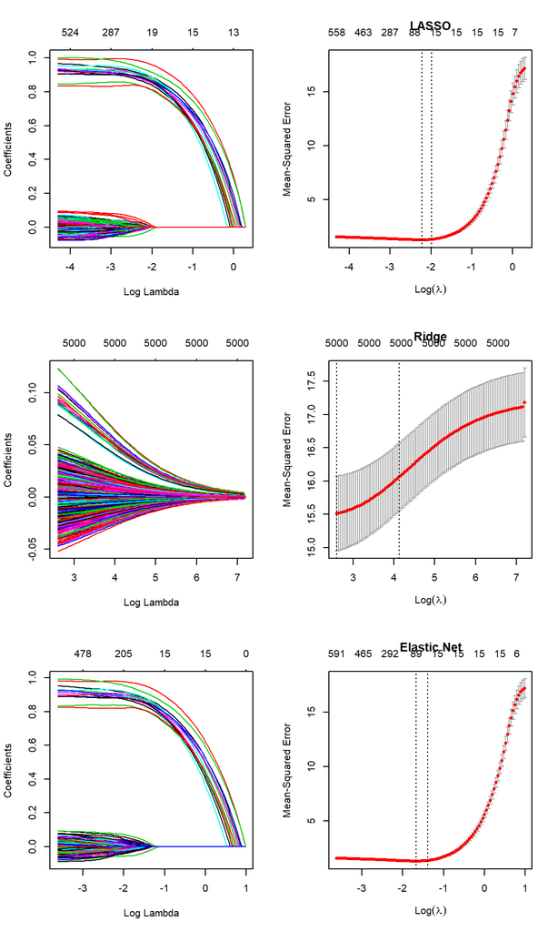

### Bayesian Regularization

`Bayesian Regularization` apply the Bayesian statistics to the regularization techniques.

- [Bayesian Regularization](http://hedibert.org/wp-content/uploads/2015/12/BayesianRegularization.pdf)
- [Mixtures of g Priors for Bayesian Variable Selection](https://people.eecs.berkeley.edu/~jordan/courses/260-spring10/readings/liang-etal.pdf)
- [29 : Posterior Regularization](https://www.cs.cmu.edu/~epxing/Class/10708-14/scribe_notes/scribe_note_lecture29.pdf)
- [New and Evolving Roles of Shrinkage in Large-Scale Prediction and Inference](https://www.birs.ca/workshops/2019/19w5188/report19w5188.pdf)
- [Shrinkage priors for Bayesian prediction](https://projecteuclid.org/euclid.aos/1151418241)

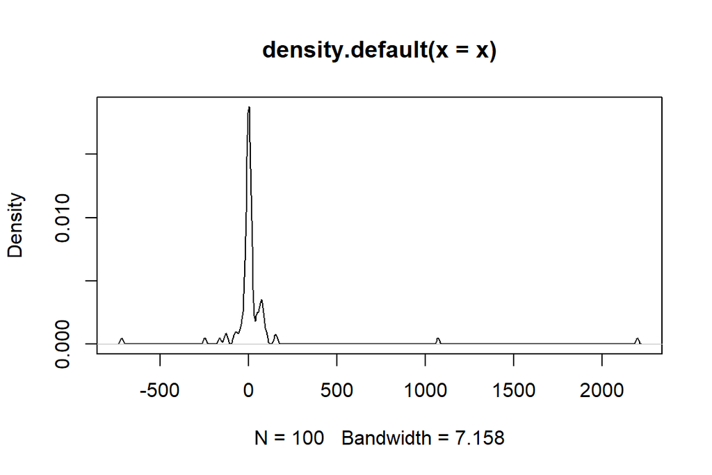

Last but not least, we introduce more on Bayesian statistics.

- https://bayesian.org/isba2020-home/
- https://www.stats.ox.ac.uk/bnp12/
- [Objections to Bayesian statistics](http://www.stat.columbia.edu/~gelman/research/published/badbayesmain.pdf)
- [The Limitation of Bayesianism](https://www.cc.gatech.edu/~isbell/classes/reading/papers/wang.bayesianism.pdf)
- [Should all Machine Learning be Bayesian? Should all Bayesian models be non-parametric?](http://gpss.cc/bark08/slides/1%20zoubin.pdf)
- http://www.math.leidenuniv.nl/~avdvaart/talks/ICM.pdf
- http://www2.stat.duke.edu/~rcs46/lectures_2015/14-bayes1/14-bayes3.pdf
- http://courses.ieor.berkeley.edu/ieor165/lecture_notes/ieor165_lec8.pdf

### Robust regression

[Robust regression can be used in any situation where OLS regression can be applied. It generally gives better accuracies over OLS because it uses a weighting mechanism to weigh down the influential observations. It is particularly resourceful when there are no compelling reasons to exclude outliers in your data.](http://r-statistics.co/Robust-Regression-With-R.html)

- https://stats.idre.ucla.edu/r/dae/robust-regression/
- [13.3 - Robust Regression Methods](https://online.stat.psu.edu/stat501/lesson/13/13.3)
- http://r-statistics.co/Robust-Regression-With-R.html

The least absolute deviation (LAD) method, which is also known as the $L_1$ method, provides a useful and plausible alternative to least squares (LS) method.

The least absolute deviation (LAD) method is to minimize
$$\sum_{i=1}^{N}|\underbrace{y_i-m(x_i;\theta)}_{\varepsilon_i}|\tag{least absolute deviation}$$
which in turn minimizes the absolute value of the residuals. In another word, $\varepsilon_i$ is generated from Laplacian distribution.

- [Analysis of least absolute deviation](https://www.math.ust.hk/~makchen/papers/LAD.pdf)

This achieves robustness, but is hard to work with in practice because the absolute value function is `not differentiable`.

[Peter Huber](https://statmodeling.stat.columbia.edu/2011/05/01/peter_hubers_th/) defines a loss function
$$\rho(r_i)=\begin{cases}\varepsilon_i^2,\text{if } |\varepsilon_i|<c,\\|2\varepsilon_i|c -c,\text{otherwise}.\end{cases}\tag{Huber}$$

`Log Hyperbolic Cosine Loss` is defined as
$$\rho(\varepsilon_i)=\log\frac{\exp(\varepsilon_i)+\exp(-\varepsilon_i)}{2}\tag{log-cosh}=\log\operatorname{cosh}(\varepsilon_i).$$

Log cosh is a smooth approxiamtion to huber loss.
$$\lim_{\varepsilon_i\to 0}\frac{\log\operatorname{cosh}(\varepsilon_i)}{\varepsilon_i^2}=1=\lim_{\varepsilon_i\to \infty}\frac{\log\operatorname{cosh}(\varepsilon_i)}{|\varepsilon_i|}.$$
- [Log Hyperbolic Cosine Loss Improves Variational Auto-Encoder](https://openreview.net/forum?id=rkglvsC9Ym)

### Penalized mle

The penalty term in Bayesian elm requires that $P(\theta)$ is a probability density (distribution) function, i.e., $\int_{x}P(x)\mathrm dx=1$. However, it is not easy to find appropriate prior. Penalized least squares are to minimize the
$$\begin{equation}\label{ Penalized mle}\arg\min_{\theta\in\mathbb{R}^p}\|y-X\theta\|_2^2+\sum_{i=1}^{p}\lambda_ip_i(|\theta_i|)\end{equation}$$
where the penalty function $p_i$ are not necessary for all $i$.

[One distinguishing feature of the nonconcave penalized likelihood approach is that it can simultaneously select variables and estimate coefficients of variables.](http://www.math.hkbu.edu.hk/~hpeng/Paper/modsel.pdf)

- [Variable Selection via Nonconcave Penalized Likelihood and its Oracle Properties](https://orfe.princeton.edu/~jqfan/papers/01/penlike.pdf)
- [Nonconcave penalized likelihood with a diverging number of parameters](https://arxiv.org/abs/math/0406466)
- https://www.sis.uta.fi/tilasto/mttapu/runze.pdf
- https://ned.ipac.caltech.edu/level5/March02/Silverman/Silver2_8.html
- https://www.ccg.unam.mx/~vinuesa/tlem/pdfs/Sanderson_PL_2002.pdf
- http://people.vcu.edu/~dbandyop/BIOS625/Penalized.pdf

### Regrssion Discontinuity Design

We can deal with the categorical independent variable. `Indicator variable, instrumental variable`

- [Endogenous Regressors and Instrumental Variables](https://eml.berkeley.edu/~powell/e240b_sp10/ivnotes.pdf)
- https://www.mailman.columbia.edu/research/population-health-methods/instrumental-variables
- [8.2 - The Basics of Indicator Variables](https://online.stat.psu.edu/stat462/node/161/)
- https://idss.mit.edu/calendar/idss-distinguished-speaker-seminar-rocio-titiunik/

## Classification Loss

Simply speacking, classification is to
$$\mathbb{R}^d\mapsto \mathbb{D}$$
where $\mathbb{D}$ is the finite categorical set.

Classification is about categorical variable. [A categorical variable (sometimes called a nominal variable) is one that has two or more categories, but there is no intrinsic ordering to the categories. For example, gender is a categorical variable having two categories (male and female) and there is no intrinsic ordering to the categories. Hair color is also a categorical variable having a number of categories (blonde, brown, brunette, red, etc.) and again, there is no agreed way to order these from highest to lowest. A purely categorical variable is one that simply allows you to assign categories but you cannot clearly order the variables.](https://stats.idre.ucla.edu/other/mult-pkg/whatstat/what-is-the-difference-between-categorical-ordinal-and-numerical-variables/)  
[If the variable has a clear ordering, then that variable would be an ordinal variable, as described below.](https://stats.idre.ucla.edu/other/mult-pkg/whatstat/what-is-the-difference-between-categorical-ordinal-and-numerical-variables/)

There is no arithmetic and magnitude concept in the world of categorical variables. Purely categorical variables are not comparable. In computer, they are always in the format of string or char. Like other common objects in computer, we can test that if two categorical variables share the same literal value.

- https://online.stat.psu.edu/stat504/node/6/

categorical encoding

- https://brendanhasz.github.io/2019/03/04/target-encoding.html
- https://www.kaggle.com/waydeherman/tutorial-categorical-encoding
- https://kiwidamien.github.io/encoding-categorical-variables.html
- https://kiwidamien.github.io/james-stein-encoder.html
- https://kiwidamien.github.io/are-you-getting-burned-by-one-hot-encoding.html
- https://rohanvarma.me/Loss-Functions/
- https://people.eecs.berkeley.edu/~wainwrig/stat241b/lec11.pdf
- https://people.cs.umass.edu/~akshay/courses/cs690m/files/lec12.pdf
- https://www.cse.huji.ac.il/~daphna/theses/Alon_Cohen_2014.pdf

### 0-1 loss and its surrogates

It is natrual to apply the 0-1 loss function in classification problems according to lack of arithmetic operation. The 0-1 loss is defined as following
$$\begin{equation}\label{0-1 loss}
L(\hat{y}, y)=\begin{cases}1,&\text{if $\hat{y}\not= y$}\\
0,&\text{if $\hat{y}= y$}\end{cases}=\mathbb{I}(\hat{y}\not= y).
\end{equation}$$
where $\mathbb{I}(\cdot)$ is the indicator function and $\hat y, y$ are categorical variables. And [this loss will induce the discrete topology space.](https://proofwiki.org/wiki/Definition:Discrete_Topology) [This metric “shatters” the points, isolating each one within its own unit ball.](https://math.stackexchange.com/questions/2614268/why-is-a-discrete-topology-called-a-discrete-topology)

- [Why is a discrete topology called a discrete topology?](https://math.stackexchange.com/questions/2614268/why-is-a-discrete-topology-called-a-discrete-topology)
- https://proofwiki.org/wiki/Category:Discrete_Topology
- https://stattrek.com/multiple-regression/dummy-variables.aspx

For example, it is common in binary classification tasks.

An n-dimensional pattern (object) $\mathbb x$ has $n$ coordinates, $x=(x_1, x_2, \cdots, x_n)$, where each $x_i$ is a real number, $x_i\in\mathbb{R}$ for $i = 1, 2,\cdots, n$. Each pattern $\mathbb x_j$ belongs to a class $y_j\in\{-1, +1\}$. Consider a training set $T$ of $m$ patterns together with their classes, $T=\{(\mathbb{x}_1, y_1), (\mathbb{x}_2, y_2), \cdots, (\mathbb{x}_m, y_m)\}$. Consider a dot product space $S$, in which the patterns $x$ are embedded, $x_1, x_2,\cdots, x_m\in S$. Any hyperplane in the space $S$ can be written as
$$\{\mathbb x\in S\mid \mathbb w\cdot\mathbb x+b=0\}, \mathbb w\in S, b\in\mathbb{R}.$$

The dot product $w\cdot\mathbb x$ is defined by:
$$\mathbb w\cdot\mathbb x=\sum_{i}^n w_ix_i$$

A training set of patterns is `linearly separable` if there exists at least one linear classifier defined by the pair $(\mathbb w, b)$ which correctly classifies all training patterns. This linear classifier is represented by the hyperplane $H$ $(\mathbb{w\cdot x}+b=0)$ and defines a region for class $+1$ patterns $(\mathbb{w\cdot x}+b>0)$ and another region for class $-1$ patterns $(\mathbb{w\cdot x}+b<0)$. The linear classifers are in the following form
$$\begin{equation}\hat{y}=\operatorname{sgn}(\mathbb{w\cdot x}+b)
=\begin{cases}1, &\text{if $\mathbb{w\cdot x}+b> 0$;}\\
-1, &\text{if $\mathbb{w\cdot x}+b< 0$.}\end{cases}
\end{equation}$$

In this case, we can reexpress the loss as following
$$\begin{equation}\tag{binary loss}\label{binay loss}
L(\hat{y}, y)=\begin{cases}1,&\text{if $\hat{y}\not= y$}\\
0,&\text{if $\hat{y}= y$}\end{cases}
=\frac{1}{2}(1-\operatorname{sgn}(\mathbb{w\cdot x}+b)y).
\end{equation}$$

The optimization procedure will minimize the loss over the training data set $T$
$$\sum_{i=1}^{m} \frac{1}{2}(1-\operatorname{sgn}(\mathbb{w\cdot x_i}+b)\mathbb{y}_i)$$
And if the positive $\alpha>0$ is small enough, we could obtain
$$(w^*, b^*)=
\arg\min_{\mathbb{w}, b} \sum_{i=1}^{m} \frac{1}{2}(1-\operatorname{sgn}(\mathbb{w\cdot x_i}+b)\mathbb{y}_i)\\=
\arg\min_{\mathbb{w}, b} \sum_{i=1}^{m} \frac{1}{2}(1-\operatorname{sgn}(\frac{1}{\alpha}[\mathbb{w\cdot x_i}+b])\mathbb{y}_i)$$
where $\alpha\leq \min\{\mathbb{w^*\cdot x_i}+b^*\mid i=1,\cdots, m\}$. The above objective is `non-differentiable and non-convex`.

If the training set $T$ is `linearly separable`, we can transfer the linear separability condition into constraints
$$\begin{equation}\label{SVM}\tag{SVM}
\begin{split}
(w^*, b^*) =&\arg\min_{\mathbb{w}, b}\frac{1}{2}\|\mathbb{w}\|_2^2 \\
&\text{subject to } \underbrace{(\mathbb{w\cdot x_i}+b)\mathbb{y}_i\geq 0}_{\text{linear separability}} \,\, i=1,\cdots,m.
\end{split}
\end{equation}$$
We prefer `the maximal margin hyperplane`
$$\begin{equation}\label{hard margine}\tag{hard margine}
\begin{split}
(w^*, b^*) =&\arg\min_{\mathbb{w}, b}\frac{1}{2}\|\mathbb{w}\|_2^2 \\
&\text{subject to } \underbrace{(\mathbb{w\cdot x_i}+b)\mathbb{y}_i\geq 1}_{\text{linear separability}} \,\, i=1,\cdots,m.
\end{split}
\end{equation}$$
where the `support vectors` are defined as $\{(\mathbb{x}_i , y_i)\mid \mathbb{w\cdot x_i}+b)=\mathbb{y}_i\}$. It is the `qudratic optimization problem with linear constraints`.

If the training set $T$ is not `linearly separable`, we prefer `the maximal soft margin hyperplane`
$$\begin{equation}\tag{soft margin}\label{soft margin}
\begin{split}
(w^*, b^*) =&\arg\min_{\mathbb{w}, b}\frac{1}{2}\|\mathbb{w}\|_2^2+\lambda\sum_{i=1}^m\varepsilon_i \\
&\text{subject to } (\mathbb{w\cdot x_i}+b)\mathbb{y}_i\geq 1- \varepsilon_i \\
& \varepsilon_i \geq 0\,\, i=1,\cdots,m.
\end{split}
\end{equation}$$
Here $\lambda > 0$ is the regularization constant.

A surrogate loss is a loss that is used as a proxy for the 0-1 loss, and usually has better computational properties such as [Hinge loss](https://en.wikipedia.org/wiki/Hinge_loss), [Ramp loss](https://www.jstor.org/stable/23013182).

- http://www.svms.org/history.html
- https://cs231n.github.io/linear-classify/
- https://www.jianshu.com/p/4a40f90f0d98

If $\varepsilon_i> 1$, we can imply that $\operatorname{sgn}(\mathbb{w\cdot x_i}+b)\not=\mathbb{y}_i$, i.e., the prediction is wrong with respect to the sample $(\mathbb{x}_i , y_i)$. And $(\mathbb{w\cdot x_i}+b)\mathbb{y}_i\geq 1- \varepsilon_i\implies \varepsilon_i\geq 1- (\mathbb{w\cdot x_i}+b)\mathbb{y}_i$, so the prediction is right if $\varepsilon_i\leq 0$. The [Hinge loss](https://www.elen.ucl.ac.be/Proceedings/esann/esannpdf/es1999-461.pdf) is defined as
$$\operatorname{H}(y_i,\hat{y}_i)=\max\{0, 1- (\underbrace{\mathbb{w\cdot x_i}+b}_{\hat y_i})y_i\}\tag{Hinge loss}$$
so `hinge loss` is $0$ when the prediction is right. The `ramp loss` is defined as following
$$\operatorname{R}(y_i,\hat{y}_i)=\min\{1,\max\{0, 1- (\underbrace{\mathbb{w\cdot x_i}+b}_{\hat y_i})y_i\}\}\tag{Ramp loss}$$
which is closer to the 0-1 loss than the hinge loss.

Note that $\lim_{t\to 0}\frac{1- t}{\exp(-t)}=1$, `Exponential Loss` is defined that
$$E(y_i,\hat y_i)=\exp(-(\mathbb{w\cdot x_i}+b)y_i).\tag{Exponential loss}$$

- [SVM for Pattern recognition](http://support-vector-machines.org/SVM_pr.html)
- http://www.ece.utep.edu/research/webfuzzy/docs/kk-thesis/kk-thesis-html/node19.html
- http://web.mit.edu/6.034/wwwbob/svm-notes-long-08.pdf
- https://en.wikipedia.org/wiki/Support-vector_machine
- https://en.wikipedia.org/wiki/Hinge_loss
- [Nonconvex online support vector machines](https://www.ncbi.nlm.nih.gov/pubmed/20513924)
- [The Support Vector Machine and Mixed Integer Linear Programming: Ramp Loss SVM with L1-Norm Regularization](https://scholarscompass.vcu.edu/cgi/viewcontent.cgi?article=1007&context=ssor_pubs)

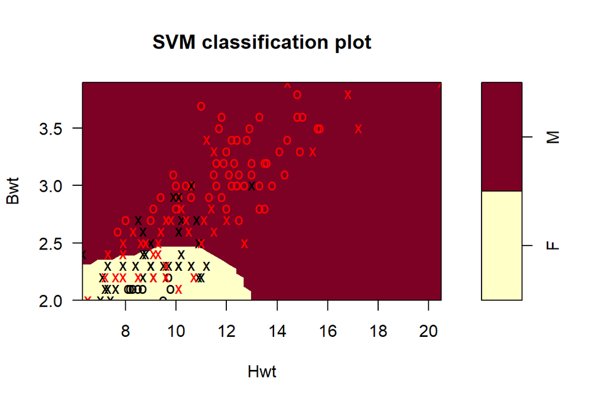

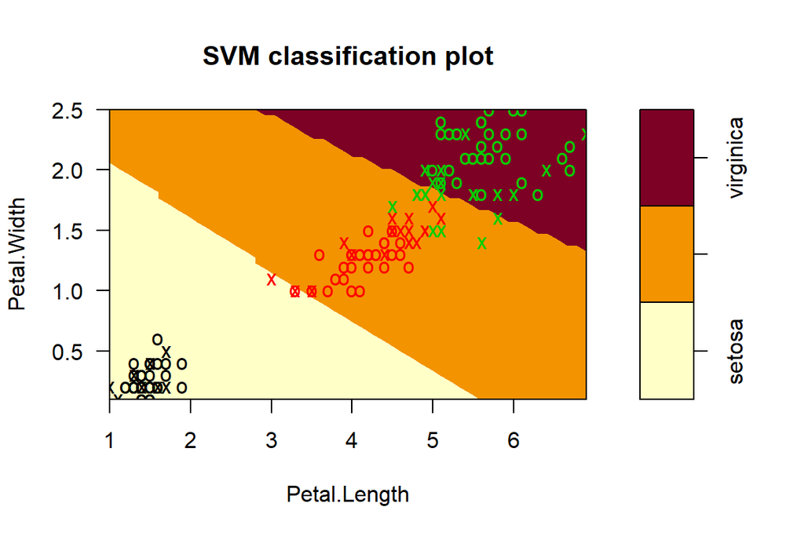

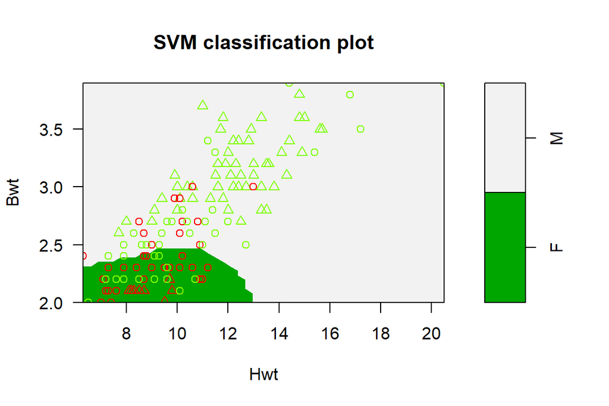

- https://arxiv.org/abs/1808.02435
- [Mixed-Integer Support Vector Machine](http://opt.kyb.tuebingen.mpg.de/papers/OPT2009-Guan.pdf)
- [OPTIMIZING $\Psi$-LEARNING VIA MIXED INTEGER PROGRAMMING](https://stat-or.unc.edu/files/2016/04/05-20.pdf)

We could interprete the linear classifer in the probalistic intepretation
$$\hat{y}=\operatorname{sgn}(\mathbb{w\cdot x}+b)=\operatorname{sgn}[\ln(\frac{P(Y=1\mid x)}{1-P(Y=1\mid x)})]$$
so that $P(Y=1\mid x)=\frac{\exp(\mathbb{w\cdot x}+b)}{1+\exp(\mathbb{w\cdot x}+b)}=\frac{1}{1+\exp(-[\mathbb{w\cdot x}+b])}$. And $P(Y\not=1\mid x)=1-\frac{\exp(\mathbb{w\cdot x}+b)}{1+\exp(\mathbb{w\cdot x}+b)}=\frac{1}{1+\exp(\mathbb{w\cdot x}+b)}$. In our setting $y_i\{+1,-1\}$, we can get that
$$P(y\mid x)=\frac{1}{1+\exp(-y[\mathbb{w\cdot x}+b])}$$
where $y\{+1,-1\}$.

We appy the maximum likelihood principle to estimate the parameters
$$\arg\max_{\mathbb w, b}\prod_{i=1}^m P(y_i\mid x_i)=\arg\min_{\mathbb w, b}\ln(\frac{1}{P(y_i\mid x_i)})\\=\arg\min_{\mathbb w, b}\ln(1+\exp(-y_i[\mathbb{w\cdot x_i}+b])).\tag{negative likellihood}$$
Note that $\lim_{z\to\infty}\frac{\ln(1+\exp(z))}{1+z}=1$ so the negative log-likelihood function is the approximation of the hinge loss.

- [Which loss function is correct for logistic regression?](https://stats.stackexchange.com/questions/250937/which-loss-function-is-correct-for-logistic-regression)
- [Why there are two different logistic loss formulation / notations?](https://stats.stackexchange.com/questions/229645/why-there-are-two-different-logistic-loss-formulation-notations)
- [Logistic Regression](https://www.stat.cmu.edu/~cshalizi/uADA/12/lectures/ch12.pdf)
- [Logistic classification model - Maximum likelihood estimation](https://www.statlect.com/fundamentals-of-statistics/logistic-model-maximum-likelihood)
- [Robustness and Regularization of Support Vector Machines](http://www.jmlr.org/papers/volume10/xu09b/xu09b.pdf)
- [The Entire Regularization Path for the Support Vector Machine](https://web.stanford.edu/~hastie/Papers/svmpath_jmlr.pdf)

Note that
$$\hat{y}=\operatorname{sgn}[\ln(\frac{P(Y=1\mid x)}{1-P(Y=1\mid x)})]=\begin{cases}+1, & \text{if } P(Y=1\mid x)> P(Y\not=1\mid x);\\ -1, &\text{if } P(Y=1\mid x)< P(Y\not=1\mid x).\end{cases}$$
If we set
$$P(Y=1\mid x)=\frac{1}{2}+\operatorname{sgn}(\mathbb{w}x+b)(1-\exp(-\|\mathbb{w}x+b\|_1))$$
so $P(Y\not=1\mid x)=\frac{1}{2}-\operatorname{sgn}(\mathbb{w}x+b)(1-\exp(-\|\mathbb{w}x+b\|_1))$. In our setting $y_i\{+1,-1\}$, we can get that
$$P(y\mid x)=\frac{1}{2}+y\operatorname{sgn}(\mathbb{w}x+b)(1-\exp(-\|\mathbb{w}x+b\|_1))$$
where $y\{+1,-1\}$. We appy the maximum likelihood principle to estimate the parameters
$$\arg\max_{\mathbb w, b}\prod_{i=1}^m P(y_i\mid x_i)=\arg\min_{\mathbb w, b}\sum_{i=1}^m -\ln [\frac{1}{2}+y_i\operatorname{sgn}(\mathbb{w}x_i+b)(1-\exp(-\|\mathbb{w}x_i+b\|_1))]$$
where $\mathbb{w}x_i+b\not= 0$. Note that $\lim_{x\to 0}\frac{-\ln(1+x)}{x}=-1$ so
$$-\ln [\frac{1}{2}+y_i\operatorname{sgn}(\mathbb{w}x_i+b)(1-\exp(-\|\mathbb{w}x_i+b\|_1))]\\ \approx \frac{1}{2}- y_i\operatorname{sgn}(\mathbb{w}x_i+b)(1-\exp(-\|\mathbb{w}x_i+b\|_1))\\ =\frac{1}{2}[1-y_i\operatorname{sgn}(\mathbb{w}x_i+b)\frac{1-\exp(-\|\mathbb{w}x_i+b\|_1)}{2}]\\=\frac{1}{2}[1-y_i\operatorname{sgn}(\mathbb{w}x_i+b)]+\frac{y_i\operatorname{sgn}(\mathbb{w}x_i+b)(1+\exp(-\|\mathbb{w}x_i+b\|_1)}{4}).$$
And we can induce more loss functions based on this approach. See [Loss functions for classification](https://en.wikipedia.org/wiki/Loss_functions_for_classification).

- https://en.wikipedia.org/wiki/Loss_functions_for_classification

If the training set $T$ is `linearly separable`, we can train a decision tree so that it defines a region for class $+1$ patterns $\mathbb{w\cdot x}+b>0$ and another region for class $-1$ patterns $\mathbb{w\cdot x}+b<0$.

In the analytic form of decision tree, it is defined as following
$$\mathbb{I}(\mathbb{w\cdot x}+b>0)-(1-\mathbb{I}(\mathbb{w\cdot x}+b>0))\tag{Decision tree}$$
where $\mathbb{I}$ is the indicator function.

The decision tree is to minimize the Split Criteria at each stage.

- [How does a Decision Tree decide where to split?](http://www.ashukumar27.io/Decision-Trees-splitting/)
- [Selecting Multiway Splits in Decision Trees](https://www.cs.waikato.ac.nz/~ml/publications/1996/Frank-Witten96.pdf)
- [Unifying the Split Criteria of Decision Trees Using Tsallis Entropy](https://arxiv.org/pdf/1511.08136.pdf)
- https://daviddalpiaz.github.io/r4sl/trees.html

### Cross-Entropy Loss

The categorical variable is really discrete variables that can take on one of finite possible mutually exclusive states.

We follow the 1-of-K scheme proposed by [Christopher Bishop](https://www.microsoft.com/en-us/research/people/cmbishop/) in [Pattern Recognition and Machine Learning](https://www.microsoft.com/en-us/research/uploads/prod/2006/01/Bishop-Pattern-Recognition-and-Machine-Learning-2006.pdf). The categorical variable is represented by a K-dimensional vector $x$  
in which one of the elements $x_k$ equals $1$, and all remaining elements equal $0$, i.e., one-hot vector. For example, we use the vector $x$ to represent gender (male and female) so $x\in\{(0, 1)^T, (1, 0)^T\}$ where $(0, 1)^T/(1, 0)^T$ corresponds male/female.

If we denote the probability of $x_k = 1$ by the parameter $\mu_k$, then the distribution of $x$ is given
$$P(x\mid \mu)=\prod_{i=1}^K\mu_i^{x_i}$$
where $\sum_{i=1}^K\mu_i=\sum_{i=1}^Kx_i=1$ and $x_i\in\{0,1\}, u_i>0$ for $i=1,\cdots,K$. And the expectation of the categorical random variable is computed by
$$\mathbb{E}(x)=\sum_{x}xP(x)=(\mu_1,\cdots,\mu_K)^T=\mu.$$
The marginal distribution for $x_k$ is given by
$$P(x_k)=\sum_{i\not=k}P(x_i)=[\sum_{i\not=k}\mu_i]^{1-x_i}\mu_i^{x_i}=(1-\mu_i)^{1-x_i}\mu_i^{x_i}$$
and the marginal expectation of $x_i$ is $\mu_i$.

- [The Multinomial Distribution](https://dipmat.univpm.it/~demeio/Alabama_PDF/11.%20Bernoulli_Trials/Multinomial.pdf)

Given two distributions $p$ and $q$ over a given variable $X$, the cross entropy is defined as
$$\begin{equation}
\label{cross}
H(p\|q)=\int_{x}p(x)\log(\frac{1}{q(x)})\mathrm d x\tag{Cross entropy}
\end{equation}$$

KL divergence in simple term is a measure of how two probability distributions (say $p$ and $q$) are different from each other.
$$\begin{equation}
\label{k-l}
KL(p\|q)=\int_{x}p(x)\log(\frac{p(x)}{q(x)})\mathrm d x
=\int_{x}p(x)[\log({p(x)})-\log({q(x)})]\mathrm d x \tag{Cross entropy}
\end{equation}$$
where $p, q$ are probability density function.

Here we cast the classification task as maximum likelihood estimate for discrete distribution.

`Generalized linear models and generalized additive models` are extension of linear models from two distinct perspectives.

Generalized linear models use nonlinear model to estimate the mean of the errors
$$\mathbb{E}(Y\mid X)=f(\theta\cdot X)\iff f^{-1}(\mathbb{E}(Y\mid X))=\theta\cdot X.\tag{GLM}$$
where $f$ is inversable nonlinear function.

Generalized additive models are defined as

$$\mathbb{E}(Y\mid X)=\sum_{i=1}^{p}f_i(\theta_i\cdot X)\tag{GAM}$$
where $f_i$ are nonlinear models.

- http://environmentalcomputing.net/intro-to-gams/
- https://m-clark.github.io/generalized-additive-models/
- [Generalized additive model](https://projecteuclid.org/download/pdf_1/euclid.ss/1177013604)

There is a natural pairing between the softmax activation function and the cross-entropy penalty function.

- [On The Pairing Of The Softmax Activation And Cross–Entropy Penalty Functions And The Derivation Of The Softmax Activation Function](https://core.ac.uk/display/24298161)
- https://arm-software.github.io/CMSIS_5/NN/html/group__Softmax.html
- https://gombru.github.io/2018/05/23/cross_entropy_loss/

#### f-Divergences

Roughly speaking, all f-divergences quantify the difference between a pair of distributions, each with different operational meaning.

- https://people.eecs.berkeley.edu/~jordan/jordan-ssg.pdf
- http://people.lids.mit.edu/yp/homepage/data/LN_fdiv.pdf
- [Inequalities for Csiszár f-Divergence in Information Theory](https://rgmia.org/monographs/csiszar_list.html)
- [ON SURROGATE LOSS FUNCTIONS AND f-DIVERGENCES1](https://projecteuclid.org/download/pdfview_1/euclid.aos/1236693153)

### Bregman Divergences

Bregman Divergences are the extension of squares of $\ell_2$. It is based on the differentiable convex function $f$ as following
$$d_f(x,y) := f(x) - f(y) - {\langle \nabla f(y), x-y \rangle} \ge 0$$
which is called the Bregman divergence induced by $f$.

- [Meet the Bregman Divergences](http://mark.reid.name/blog/meet-the-bregman-divergences.html)
- https://papers.nips.cc/paper/8094-generalized-cross-entropy-loss-for-training-deep-neural-networks-with-noisy-labels.pdf

### Circle loss

- [Circle Loss: A Unified Perspective of Pair Similarity Optimization](https://arxiv.org/pdf/2002.10857v1.pdf)
- https://github.com/TinyZeaMays/CircleLoss
- https://zhuanlan.zhihu.com/p/45014864

## Ranking loss

Learning to rank is another kind of supervised learning task.

- https://pub.ist.ac.at/~vnk/papers/MRJKK-CVPR2018.pdf
- https://gombru.github.io/2019/04/03/ranking_loss/

## Metric learning

- https://ai.stanford.edu/~ang/papers/nips02-metric.pdf
- http://www.jmlr.org/papers/volume10/weinberger09a/weinberger09a.pdf